# survey-results

Erik Ø. Sørensen

16 januar, 2026

```r
library(tidyverse)
library(multiwayvcov)
library(here)
library(multcomp)
library(gt)
require(targets)
require(patchwork)
source(here::here("R","utility.R"))
source(here::here("R","data_transforms.R"))
source(here::here("R","survey_functions.R"))
tar_load(mmtalent)
```

# Figures on attitudes and belief

To have the main result on attitudes and belief, we would like to have aggregate patterns before going into the individual level data.

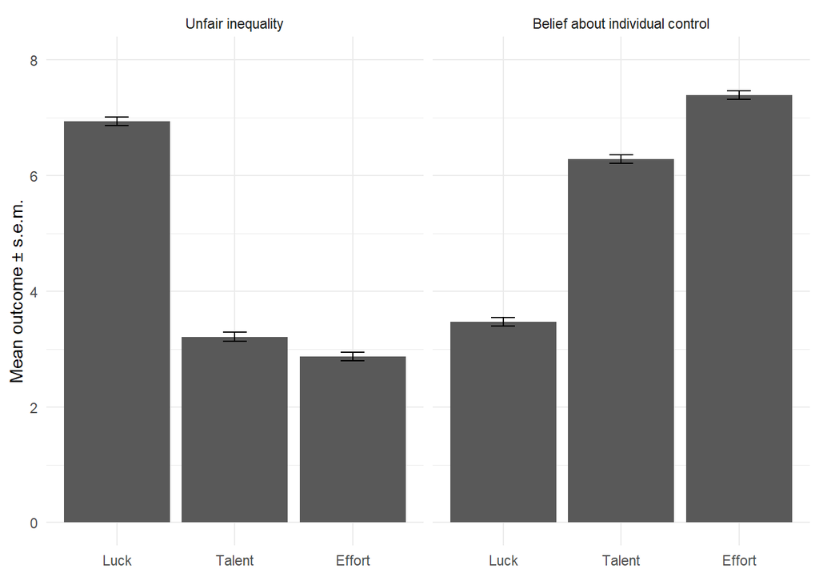

Testing differences, unfairness:

```r
mmtalent |> pivot_longer(cols=c("luck_fair", "talent_fair"), names_to="a", values_to="unfairness") |>
  lm(unfairness ~ a, weight=wgt, data=_) |> summary()
```

```
##
## Call:
## lm(formula = unfairness ~ a, data = pivot_longer(mmtalent, cols = c("luck_fair",
##     "talent_fair"), names_to = "a", values_to = "unfairness"),
##     weights = wgt)
##
## Weighted Residuals:
##      Min       1Q   Median       3Q      Max
## -10.9307  -2.2169  -0.1575   2.1685  12.5998
##
## Coefficients:
##              Estimate Std. Error t value Pr(>|t|)
## (Intercept)   6.94424    0.06691  103.79   <2e-16 ***
## atalent_fair -3.73070    0.09462  -39.43   <2e-16 ***
## ---
## Signif. codes:  0 '***' 0.001 '**' 0.01 '*' 0.05 '.' 0.1 ' ' 1
##
## Residual standard error: 2.993 on 4000 degrees of freedom
## Multiple R-squared:  0.2799, Adjusted R-squared:  0.2797
## F-statistic:  1555 on 1 and 4000 DF,  p-value: < 2.2e-16
```

```r
mmtalent |> pivot_longer(cols=c("effort_fair", "talent_fair"), names_to="b", values_to="unfairness") |>
  lm(unfairness ~ b, weight=wgt, data=_) |> summary()
```

```
##
## Call:
## lm(formula = unfairness ~ b, data = pivot_longer(mmtalent, cols = c("effort_fair",
##     "talent_fair"), names_to = "b", values_to = "unfairness"),
##     weights = wgt)
##
## Weighted Residuals:
##     Min      1Q  Median      3Q     Max
## -6.4637 -2.2305 -0.8612  1.7972 12.5998
##
## Coefficients:
##              Estimate Std. Error t value Pr(>|t|)
## (Intercept)   2.86839    0.06672  42.992  < 2e-16 ***
## btalent_fair  0.34515    0.09435   3.658 0.000257 ***
## ---
## Signif. codes:  0 '***' 0.001 '**' 0.01 '*' 0.05 '.' 0.1 ' ' 1
##
## Residual standard error: 2.984 on 4000 degrees of freedom
## Multiple R-squared:  0.003334,   Adjusted R-squared:  0.003085
## F-statistic: 13.38 on 1 and 4000 DF,  p-value: 0.0002575
```

Testing differences, control:

```r
mmtalent |> pivot_longer(cols=c("luck_control", "talent_control"), names_to="a", values_to="control") |>
  lm(control ~ a, weight=wgt, data=_) |> summary()
```

```
##
## Call:
## lm(formula = control ~ a, data = pivot_longer(mmtalent, cols = c("luck_control",
##     "talent_control"), names_to = "a", values_to = "control"),
##     weights = wgt)
##
## Weighted Residuals:
##      Min       1Q   Median       3Q      Max
## -11.6707  -2.3453  -0.2812   1.9736  11.1238
##
## Coefficients:
##                 Estimate Std. Error t value Pr(>|t|)
## (Intercept)      3.46958    0.06580   52.73   <2e-16 ***
## atalent_control  2.81645    0.09305   30.27   <2e-16 ***
## ---
## Signif. codes:  0 '***' 0.001 '**' 0.01 '*' 0.05 '.' 0.1 ' ' 1
##
## Residual standard error: 2.943 on 4000 degrees of freedom
## Multiple R-squared:  0.1864, Adjusted R-squared:  0.1861
## F-statistic: 916.1 on 1 and 4000 DF,  p-value: < 2.2e-16
```

```r
mmtalent |> pivot_longer(cols=c("effort_control", "talent_control"), names_to="b", values_to="control") |>
  lm(control ~ b, weight=wgt, data=_) |> summary()
```

```
##
## Call:
## lm(formula = control ~ b, data = pivot_longer(mmtalent, cols = c("effort_control",
##     "talent_control"), names_to = "b", values_to = "control"),
##     weights = wgt)
##
## Weighted Residuals:
##      Min       1Q   Median       3Q      Max
## -13.7214  -1.9633   0.6468   2.1545   7.4702
##
## Coefficients:
##                 Estimate Std. Error t value Pr(>|t|)
## (Intercept)      7.39060    0.06569  112.51   <2e-16 ***
## btalent_control -1.10456    0.09290  -11.89   <2e-16 ***
## ---
## Signif. codes:  0 '***' 0.001 '**' 0.01 '*' 0.05 '.' 0.1 ' ' 1
##
## Residual standard error: 2.939 on 4000 degrees of freedom
## Multiple R-squared:  0.03414,    Adjusted R-squared:  0.03389
## F-statistic: 141.4 on 1 and 4000 DF,  p-value: < 2.2e-16
```

```r
long_attitudes(mmtalent) |>
  group_by(outcometype, fo, outcome) |>
    summarize(m = weighted.mean(value, wgt),
              se = weighted.se(value, wgt))
```

```
## # A tibble: 6 × 5
## # Groups:   outcometype, fo [6]
##   outcometype                     fo     outcome     m     se
##   <fct>                           <fct>  <chr>   <dbl>  <dbl>
## 1 Unfair inequality               Luck   AL       6.94 0.0747
## 2 Unfair inequality               Talent AT       3.21 0.0750
## 3 Unfair inequality               Effort AE       2.87 0.0739
## 4 Belief about individual control Luck   CL       3.47 0.0760
## 5 Belief about individual control Talent CT       6.29 0.0732
## 6 Belief about individual control Effort CE       7.39 0.0731
```

And the corresponding histograms:

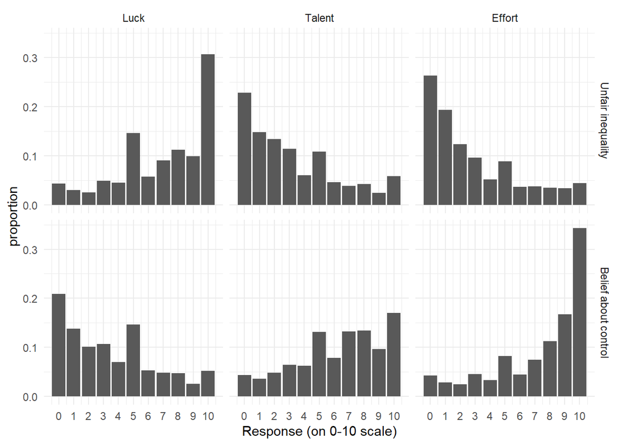

```r
long_attitudes(mmtalent) %>%
  mutate(outcometype = fct_recode(
    outcometype,
    "Belief about control" = "Belief about individual control"
  )) %>%
  group_by(outcometype, fo) %>%
  summarize(weighted.bars(value, wgt)) %>%
  ggplot(aes(x=v, y=proportion)) +
  geom_col() +
  theme_minimal() +
  labs(x = "Response (on 0-10 scale)") +
  scale_x_continuous(breaks=c(0,1,2,3,4,5,6,7,8,9,10)) +
  facet_grid(outcometype ~ fo)
```

```r
ggsave(here::here("figures","attitude_histograms.pdf"), width = 16, height = 10, units = "cm")
```

# Subgroups

First for the division of all data into binary groups:

[figure not shown]

```r
long_attitudes(mmtalent) %>%
  mutate(outcometype = fct_recode(
    outcometype,
    "Belief about control" = "Belief about individual control"
  )) %>%
  survey_bars_by_subgroup() %>%
  patchwork::wrap_plots() + plot_layout(ncol=2) + plot_annotation(tag_levels = "a")
```

```r
ggsave(here::here("figures","attitudes_beliefs_by_subgroups.pdf"), width = 30, height = 50, units="cm")
```

Now with all the $2^5$ combinations:

[figure not shown]

```r
long_attitudes(mmtalent) %>%
  mutate(outcometype = fct_recode(
    outcometype,
    "Belief about control" = "Belief about individual control"
  )) %>%
  survey_bars_by_subgroup_cross() %>%
  patchwork::wrap_plots() + plot_layout(ncol=4) + plot_annotation(tag_levels = "1")
```

```r
ggsave(here::here("figures","attitudes_beliefs_by_subgroups_cross.pdf"), width = 30, height = 50, units="cm")
```

# Regression table

We want to put attitudes on the left hand side and try to explain it by the type of attitude and the perception of control in the situation.

Now, we need to turn the data around a bit first:

```r
tar_load(subjectives_dt)
subjectives_dt %>% sample_n(3)
```

```
## # A tibble: 3 × 17
##      id fo     treatment gender   age age_high left  high_income income_category
##   <int> <fct>  <fct>     <fct>  <dbl>    <dbl> <lgl> <lgl>       <fct>
## 1  1495 Effort ExAnteIm… female    54        1 FALSE TRUE        60k - 99 999
## 2  1322 Talent ExAnteIm… female    19        0 FALSE FALSE       Less than 29 9…
## 3   160 Talent ExAntePe… female    21        0 FALSE FALSE       Less than 29 9…
## # ℹ 8 more variables: high_edu <lgl>, edu_category <fct>, wgt <dbl>,
## #   `Unfair inequality` <dbl>, `Belief about individual control` <dbl>,
## #   Luck <dbl>, Effort <dbl>, Talent <dbl>
```

Now, it is possible to run the regression
$$A_{i,t} = \beta_0 + \beta_1 B_{i,t} + \beta_2
X_i + \phi_t + \epsilon_{i,t},$$
where $i$ index the individual, and $t\in\{ \mathrm{effort}, \mathrm{talent}, \mathrm{luck}\}$, $A_{i,t}\in[0,10]$ is the fairness attitude, $B_{i,t}\in[0,10]$ is the control belief, $X_i$ is a set of individual controls, and $\phi_t$ is a set of fixed effect for each factor.

```r
tar_load(survey_regressions_list)
survey_names <- c('Talent'='Talent (d)',
                  'Effort'='Effort (d)',
                   'Belief about individual control'='Belief about control (0-10)',
                  'Talent:Belief about individual control' = 'Talent x Belief about control',
                  'Effort:Belief about individual control' = 'Effort x Belief about control',
                  'age_high' = 'High age (d)',
                  'leftTRUE' = 'Left (d)',
                  'high_incomeTRUE' = 'High income (d)',
                  'high_eduTRUE' = 'High education (d)',
                  'maleTRUE' = 'Male (d)',
                  'treatmentExAntePersonal' = "Treatment: Ex Ante Personal (d)",
                  'treatmentExAnteImpersonal'   = "Treatment: Ex Ante Impersonal (d)",
                  'treatmentExPostPersonal' = "Treatment: Ex Post Personal (d)",
                  '(Intercept)'='(Intercept)')
```

|  | Unfairness of Talent,Effort,Luck determining income (1) | Unfairness of Talent,Effort,Luck determining income (2) | Unfairness of Talent,Effort,Luck determining income (3) | Unfairness of Talent,Effort,Luck determining income (4) | Unfairness of Talent,Effort,Luck determining income (5) |
| --- | --- | --- | --- | --- | --- |
| Talent (d) | -3.731*** | -3.376*** | -3.373*** | -3.467*** | -3.391*** |
|  | (0.107) | (0.109) | (0.206) | (0.210) | (0.109) |
| Effort (d) | -4.076*** | -3.582*** | -3.267*** | -3.430*** | -3.602*** |
|  | (0.111) | (0.121) | (0.225) | (0.231) | (0.122) |
| Belief about control (0-10) |  | -0.126*** | -0.104*** | -0.115*** | -0.121*** |
|  |  | (0.019) | (0.027) | (0.028) | (0.019) |
| Talent x Belief about control |  |  | -0.010 | 0.010 |  |
|  |  |  | (0.035) | (0.036) |  |
| Effort x Belief about control |  |  | -0.054 | -0.026 |  |
|  |  |  | (0.033) | (0.034) |  |
| High age (d) |  |  |  | -0.432*** | -0.438*** |
|  |  |  |  | (0.105) | (0.102) |
| Left (d) |  |  |  | 0.119 | 0.116 |
|  |  |  |  | (0.114) | (0.115) |
| High income (d) |  |  |  | -0.147 | -0.148 |
|  |  |  |  | (0.108) | (0.108) |
| High education (d) |  |  |  | -0.195* | -0.197* |
|  |  |  |  | (0.110) | (0.110) |
| Male (d) |  |  |  | 0.175* | 0.178* |
|  |  |  |  | (0.101) | (0.101) |
| (Intercept) | 6.944*** | 7.381*** | 7.306*** | 7.619*** | 7.642*** |
|  | (0.075) | (0.102) | (0.121) | (0.148) | (0.127) |
| Num.Obs. | 6003 | 6003 | 6003 | 6003 | 6003 |
| R2 | 0.277 | 0.288 | 0.288 | 0.294 | 0.294 |
| AIC | 30947.7 | 30855.8 | 30856.4 | 30819.2 | 30816.5 |
| BIC | 30974.5 | 30889.3 | 30903.3 | 30899.6 | 30883.5 |
| RMSE | 3.02 | 3.01 | 3.01 | 3.00 | 3.00 |
| Std.Errors | by: id | by: id | by: id | by: id | by: id |

* p < 0.1, ** p < 0.05, *** p < 0.01

```r
names(survey_regressions_list$without_treatment[[4]]$coefficients) <- make.names(names(survey_regressions_list$without_treatment[[4]]$coefficients))
car::linearHypothesis(survey_regressions_list$without_treatment[[4]], c("Talent - Effort = 0",
                                                                        "X.Belief.about.individual.control. - Effort..Belief.about.individual.control. = 0"))
```

```
##
## Linear hypothesis test:
## Talent - Effort = 0
## X.Belief.about.individual.control. - Effort..Belief.about.individual.control. = 0
##
## Model 1: restricted model
## Model 2: `Unfair inequality` ~ Talent + Effort + Talent * `Belief about individual control` +
##     Effort * `Belief about individual control` + `Belief about individual control` +
##     age_high + left + high_income + high_edu + male
##
##   Res.Df Df  Chisq Pr(>Chisq)
## 1   5994
## 2   5992  2 2.7887      0.248
```

# Are there treatment effects on attitudes?

The survey came after the experiment. Are there any treatment effect on the survey outcomes?

The simplest is to repeat the main regression table with dummies for treatment. We test for joint significance of the treatment dummies.

```r
surv_joint_tests <- c(car::linearHypothesis(survey_regressions_list$with_treatment[[1]],
                            c("treatmentExAntePersonal = 0",
                              "treatmentExPostPersonal = 0",
                              "treatmentExAnteImpersonal = 0"))$`Pr(>Chisq)`[2],
                      car::linearHypothesis(survey_regressions_list$with_treatment[[2]],
                            c("treatmentExAntePersonal = 0",
                              "treatmentExPostPersonal = 0",
                              "treatmentExAnteImpersonal = 0"))$`Pr(>Chisq)`[2],
                      car::linearHypothesis(survey_regressions_list$with_treatment[[3]],
                            c("treatmentExAntePersonal = 0",
                              "treatmentExPostPersonal = 0",
                              "treatmentExAnteImpersonal = 0"))$`Pr(>Chisq)`[2],
                      car::linearHypothesis(survey_regressions_list$with_treatment[[4]],
                            c("treatmentExAntePersonal = 0",
                              "treatmentExPostPersonal = 0",
                              "treatmentExAnteImpersonal = 0"))$`Pr(>Chisq)`[2],
                      car::linearHypothesis(survey_regressions_list$with_treatment[[5]],
                            c("treatmentExAntePersonal = 0",
                              "treatmentExPostPersonal = 0",
                              "treatmentExAnteImpersonal = 0"))$`Pr(>Chisq)`[2])
surv_joint_tests_wrow <- tibble::tribble(~v, ~p1, ~p2, ~p3, ~p4, ~p5,
                        "Joint p-value on treatment dummies:",
                        sprintf("%4.3f", surv_joint_tests[1]),
                        sprintf("%4.3f", surv_joint_tests[2]),
                        sprintf("%4.3f", surv_joint_tests[3]),
                        sprintf("%4.3f", surv_joint_tests[4]),
                        sprintf("%4.3f", surv_joint_tests[5]))
```

[output not shown]

* p < 0.1, ** p < 0.05, *** p < 0.01

We test for joint significance of the treatment effects for each of the 6 outcomes.

```r
A1 <- lm(luck_fair ~ treatment, data = mmtalent)
A1w <- car::linearHypothesis(A1, c("treatmentExAntePersonal = 0",
                          "treatmentExPostPersonal = 0",
                          "treatmentExAnteImpersonal = 0"))
A2 <- lm(talent_fair ~ treatment, data = mmtalent)
A2w <- car::linearHypothesis(A2, c("treatmentExAntePersonal = 0",
                          "treatmentExPostPersonal = 0",
                          "treatmentExAnteImpersonal = 0"))
A3 <- lm(effort_fair ~ treatment, data = mmtalent)
A3w <- car::linearHypothesis(A3, c("treatmentExAntePersonal = 0",
                          "treatmentExPostPersonal = 0",
                          "treatmentExAnteImpersonal = 0"))
B1 <- lm(luck_control ~ treatment, data = mmtalent)
B1w <- car::linearHypothesis(B1, c("treatmentExAntePersonal = 0",
                          "treatmentExPostPersonal = 0",
                          "treatmentExAnteImpersonal = 0"))
B2 <- lm(talent_control ~ treatment, data = mmtalent)
B2w <- car::linearHypothesis(B2, c("treatmentExAntePersonal = 0",
                          "treatmentExPostPersonal = 0",
                          "treatmentExAnteImpersonal = 0"))
B3 <- lm(effort_control ~ treatment, data = mmtalent)
B3w <- car::linearHypothesis(B3, c("treatmentExAntePersonal = 0",
                          "treatmentExPostPersonal = 0",
                          "treatmentExAnteImpersonal = 0"))

wrow <- tibble::tribble(~v, ~p1, ~p2, ~p3, ~p4, ~p5, ~p6,
                        "Joint p-value on treatment dummies:",
          sprintf("%4.3f", A1w$`Pr(>F)`[2]),
          sprintf("%4.3f", A2w$`Pr(>F)`[2]),
          sprintf("%4.3f", A3w$`Pr(>F)`[2]),
          sprintf("%4.3f", B1w$`Pr(>F)`[2]),
          sprintf("%4.3f", B2w$`Pr(>F)`[2]),
          sprintf("%4.3f", B3w$`Pr(>F)`[2]))

modelsummary::modelsummary(list("A.luck"=A1, "A.talent"=A2, "A.effort"=A3, "B.luck"=B1, "B.talent"=B2, "B.effort"=B3),
                           stars = c('*'=0.1, '**'=0.05, '***'=0.01),
                           gof_omit = "R2 Adj.|AIC|BIC|Log.Lik.|F",
                           output="gt",
                           add_rows = wrow) |>
  gt::tab_spanner(label="Unfair inequality", columns=2:4) |>
  gt::tab_spanner(label="Belief about individual control", columns = 5:7)
```

|  | Unfair inequality A.luck | Unfair inequality A.talent | Unfair inequality A.effort | Belief about individual control B.luck | Belief about individual control B.talent | Belief about individual control B.effort |
| --- | --- | --- | --- | --- | --- | --- |
| (Intercept) | 6.837*** | 3.113*** | 2.728*** | 3.282*** | 6.270*** | 7.324*** |
|  | (0.137) | (0.136) | (0.134) | (0.135) | (0.133) | (0.138) |
| treatmentExAnteImpersonal | -0.127 | 0.107 | 0.177 | 0.141 | -0.175 | -0.020 |
|  | (0.193) | (0.192) | (0.189) | (0.190) | (0.188) | (0.195) |
| treatmentExAntePersonal | 0.005 | 0.031 | 0.056 | 0.261 | 0.084 | -0.130 |
|  | (0.193) | (0.192) | (0.189) | (0.190) | (0.188) | (0.195) |
| treatmentExPostPersonal | 0.066 | 0.397** | 0.380** | 0.218 | -0.258 | -0.126 |
|  | (0.193) | (0.192) | (0.188) | (0.189) | (0.187) | (0.194) |
| Num.Obs. | 2001 | 2001 | 2001 | 2001 | 2001 | 2001 |
| R2 | 0.001 | 0.003 | 0.002 | 0.001 | 0.002 | 0.000 |
| RMSE | 3.05 | 3.03 | 2.98 | 3.00 | 2.97 | 3.07 |
| Joint p-value on treatment dummies: | 0.787 | 0.145 | 0.187 | 0.534 | 0.242 | 0.861 |

* p < 0.1, ** p < 0.05, *** p < 0.01

We see that 2 out of 18 treatment effects are significant at the 10% level, which is not surprising even under the null of no true effect, and the joint p-values are all above 10%.

## Heterogeneity of talent paradox estimates

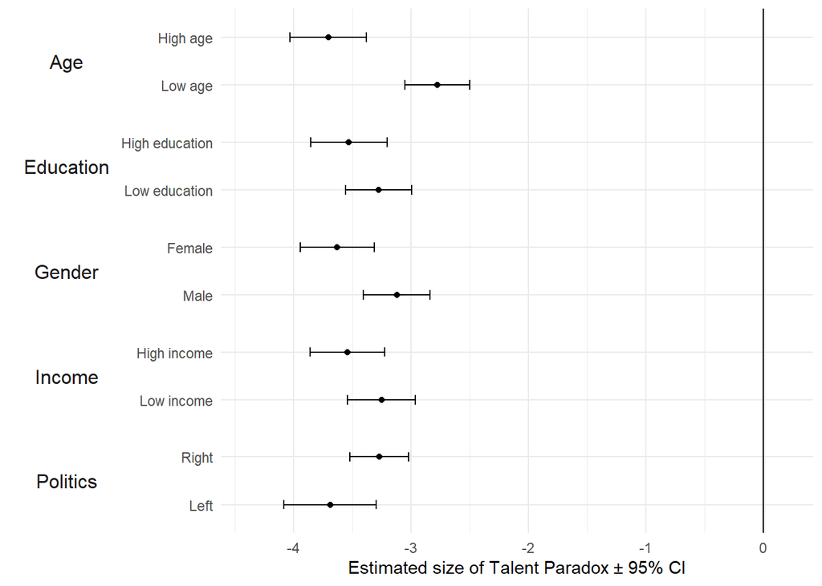